# Deep Analysis: Trading Bot Performance & Model Diagnostics

```
  Using cached xgboost-3.2.0-py3-none-macosx_12_0_arm64.whl.metadata (2.1 kB)
Using cached xgboost-3.2.0-py3-none-macosx_12_0_arm64.whl (2.3 MB)
Imports OK
```

```
Total trades in DB:     411
Resolved trades:        167
Live snapshots:         9644
Unique games (trades):  28
Unique games (snaps):   49
Live features:          255
Pregame features:       160
Edge features:          259
```

## Section 1: Resolved Trade Log & Calibration Curve

```
================================================================================
  RESOLVED TRADE LOG  —  167 trades
================================================================================
  Total PnL:    $-19.89
  Win rate:     47.9%
  Avg PnL/trade: $-0.12
  Max win:      $221.67
  Max loss:     $-46.88
================================================================================
```

|  | timestamp | game_id | target_team | action | model_implied_prob | market_implied_prob | bought_home | home_score | away_score | period | secs_left | pnl | won |
| --- | --- | --- | --- | --- | --- | --- | --- | --- | --- | --- | --- | --- | --- |
| 9 | 2026-03-15 04:05:30 | 0x671b141d... | Clippers | SELL(TRAILING_STOP(peak 0.540 now 0.490)) | 0.1644 | 0.49 | 0 | NaN | NaN | NaN | NaN | 24.24 | 1 |
| 11 | 2026-03-15 04:20:57 | 0x671b141d... | Clippers | SELL(TRAILING_STOP(peak 0.730 now 0.670)) | 0.1305 | 0.67 | 0 | NaN | NaN | NaN | NaN | 18.37 | 1 |
| 14 | 2026-03-15 04:36:18 | 0x671b141d... | Clippers | SELL(EDGE_FLIP(was -0.192 now +0.060)) | 0.1698 | 0.89 | 0 | NaN | NaN | NaN | NaN | 16.42 | 1 |
| 16 | 2026-03-15 04:38:12 | 0x671b141d... | Clippers | SELL(TRAILING_STOP(peak 0.240 now 0.180)) | 0.2503 | 0.18 | 1 | NaN | NaN | NaN | NaN | 31.82 | 1 |
| 18 | 2026-03-15 04:41:19 | 0x671b141d... | Clippers | SELL(EDGE_FLIP(was +0.070 now -0.050)) | 0.1698 | 0.22 | 1 | NaN | NaN | NaN | NaN | 11.11 | 1 |
| ... | ... | ... | ... | ... | ... | ... | ... | ... | ... | ... | ... | ... | ... |
| 401 | 2026-03-21 02:43:39 | 0x758ed7ee... | Nuggets | SELL(TRAILING_STOP(peak 0.660 now 0.600)) | 0.1196 | 0.40 | 0 | 74.0 | 84.0 | 3.0 | 928.0 | 6.60 | 1 |
| 403 | 2026-03-21 02:55:12 | 0x758ed7ee... | Nuggets | SELL(STOP_LOSS(entry 0.600 now 0.440)) | 0.0864 | 0.56 | 0 | 90.0 | 94.0 | 4.0 | 647.0 | -13.33 | 0 |
| 405 | 2026-03-21 03:03:03 | 0x758ed7ee... | Nuggets | SELL(STOP_LOSS(entry 0.440 now 0.260)) | 0.1138 | 0.74 | 0 | 95.0 | 96.0 | 4.0 | 554.0 | -20.45 | 0 |
| 407 | 2026-03-21 03:04:13 | 0x758ed7ee... | Nuggets | SELL(TRAILING_STOP(peak 0.470 now 0.410)) | 0.2634 | 0.59 | 0 | 98.0 | 99.0 | 4.0 | 471.0 | 25.93 | 1 |
| 409 | 2026-03-21 03:07:15 | 0x758ed7ee... | Nuggets | SELL(STOP_LOSS(entry 0.390 now 0.230)) | 0.2282 | 0.77 | 0 | 101.0 | 101.0 | 4.0 | 360.0 | -20.51 | 0 |

167 rows × 13 columns

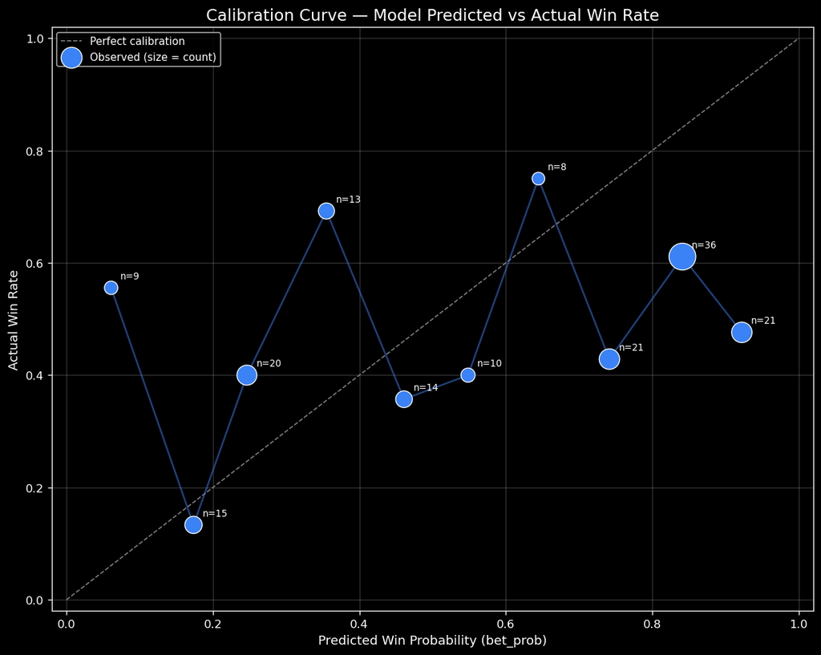

```
  CALIBRATION TABLE
  ============================================================
  Bin                     Count  Pred Mean  Actual WR
  ------------------------------------------------------------
  (0.0124, 0.11]              9     0.0611     0.5556
  (0.11, 0.207]              15     0.1736     0.1333
  (0.207, 0.303]             20     0.2465     0.4000
  (0.303, 0.4]               13     0.3550     0.6923
  (0.4, 0.497]               14     0.4610     0.3571
  (0.497, 0.594]             10     0.5484     0.4000
  (0.594, 0.69]               8     0.6445     0.7500
  (0.69, 0.787]              21     0.7415     0.4286
  (0.787, 0.884]             36     0.8411     0.6111
  (0.884, 0.98]              21     0.9223     0.4762
  ============================================================
```

## Section 2: XGBoost Feature Importances

Load all 4 XGBoost sub-models (win_probability, margin, market_proxy, edge_model), extract feature importance by gain, and compare which features drive each model.

```
  win_probability     : 246 features with importance, top = MARGIN (568.4)
  margin              : 252 features with importance, top = MARGIN_X_PROGRESS (37582.5)
  market_proxy        : 154 features with importance, top = DIFF_STATIC_NET_RATING_FADED (996.0)
  edge_model          : 244 features with importance, top = ABS_MARGIN_OVER_SQRT_TIME (242.2)

All models loaded successfully.
```

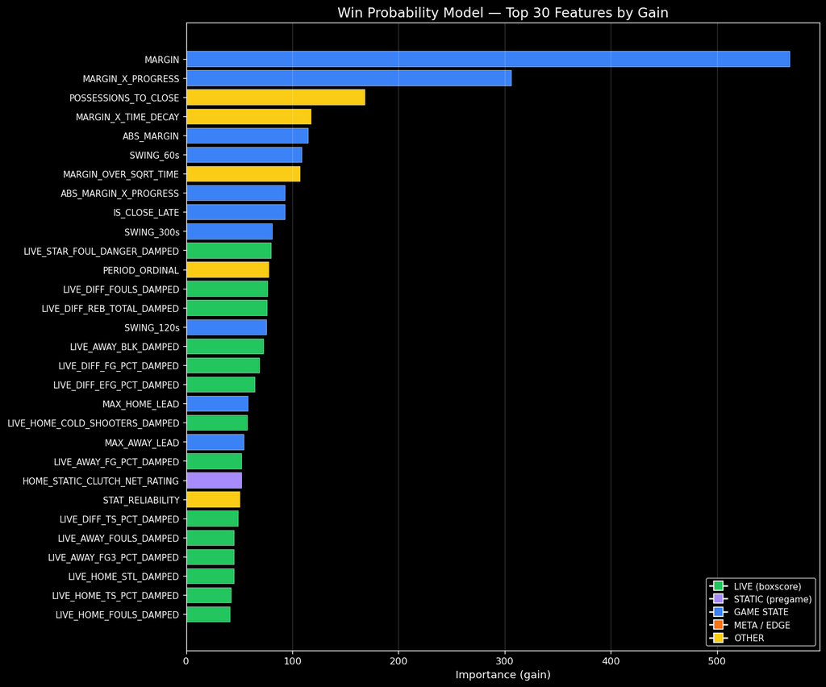

```
  TOP FEATURES ACROSS ALL 4 MODELS (sorted by win_probability importance)
  ==============================================================================================================
  Feature                             Category              WinProb     Margin   MktProxy       Edge
  --------------------------------------------------------------------------------------------------------------
  MARGIN                              GAME STATE              568.4    30641.3        0.0       40.2
  MARGIN_X_PROGRESS                   GAME STATE              306.2    37582.5        0.0       21.1
  POSSESSIONS_TO_CLOSE                OTHER                   168.2    32091.1        0.0       63.8
  MARGIN_X_TIME_DECAY                 OTHER                   117.2    14901.5        0.0       21.5
  ABS_MARGIN                          GAME STATE              114.8     5459.0        0.0       37.1
  SWING_60s                           GAME STATE              108.7     2891.0        0.0       24.8
  MARGIN_OVER_SQRT_TIME               OTHER                   107.2    15463.0        0.0       21.5
  ABS_MARGIN_X_PROGRESS               GAME STATE               92.9     6756.8        0.0       69.1
  IS_CLOSE_LATE                       GAME STATE               92.7     3002.7        0.0        0.0
  SWING_300s                          GAME STATE               80.7     2476.8        0.0       18.7
  LIVE_STAR_FOUL_DANGER_DAMPED        LIVE (boxscore)          79.7      202.5        0.0       19.9
  PERIOD_ORDINAL                      OTHER                    77.4      433.6        0.0       32.2
  LIVE_DIFF_FOULS_DAMPED              LIVE (boxscore)          76.8      130.3        0.0       17.8
  LIVE_DIFF_REB_TOTAL_DAMPED          LIVE (boxscore)          76.1      264.4        0.0       14.4
  SWING_120s                          GAME STATE               75.2     1743.4        0.0       24.2
  LIVE_DIFF_FG_PCT_DAMPED             LIVE (boxscore)          69.0     1734.6        0.0       12.3
  MAX_HOME_LEAD                       GAME STATE               58.0    18601.7        0.0       20.5
  MAX_AWAY_LEAD                       GAME STATE               54.0    12241.9        0.0       20.3
  HOME_STATIC_CLUTCH_NET_RATING       STATIC (pregame)         51.7      290.5      162.4       35.6
  LEAD_CHANGES                        GAME STATE               40.4      348.0        0.0       85.6
  ==============================================================================================================

  FEATURE CATEGORY BREAKDOWN (win_probability model, all features):
                  count   total_gain   avg_gain
category
GAME STATE           32  2019.045778  63.095181
STATIC (pregame)    157  1713.107719  10.911514
LIVE (boxscore)      48  1516.226969  31.588062
OTHER                 9   596.958032  66.328670
```

## Section 3: Live Snapshot Time Series for 3 Games

Visualize model vs market probability and score margin over game time for three selected games:

- **SAC vs UTA (Kings game)** — Profitable (+$200 PnL)
- **HOU vs LAL (Rockets game)** — Losing
- **LAC vs SAC (Clippers game)** — Mixed

Trade entry/exit points are overlaid from the trades database.

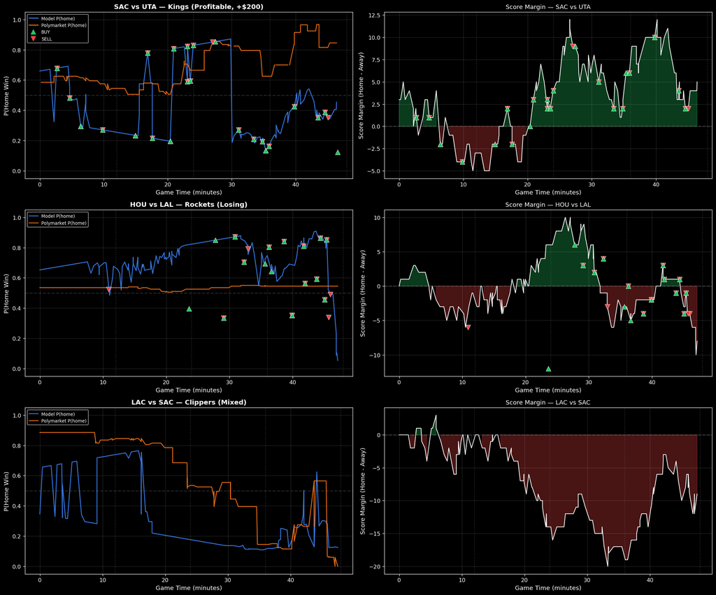

```
  SAC vs UTA — Kings (Profitable, +$200)
    Trades: 46 total, 18 resolved, PnL: $200.26

  HOU vs LAL — Rockets (Losing)
    Trades: 34 total, 17 resolved, PnL: $-59.57

  LAC vs SAC — Clippers (Mixed)
    Trades: 28 total, 11 resolved, PnL: $36.30
```

## Section 4: Buy/Sell Sequencing & Round-Trip Analysis

Analyze trading patterns per game: buy/sell counts, round-trip sequences (buy-sell-buy cycles), and whether more frequent trading correlates with better or worse PnL.

```
  BUY/SELL SEQUENCING SUMMARY
  ================================================================================
  Total unique games traded:  38
  Avg trades per game:        10.8
  Games with >5 trades:       16
  Games with >10 trades:      14
  Total round-trips:          160
  Games with round-trips:     27

  Correlation (trade count vs PnL): +0.497
  Correlation (round-trips vs PnL): +0.463

  Game                                      Trades  Buys  Sells  RTs        PnL
  --------------------------------------------------------------------------------
  0x40e9eade... Trail Blazers vs. 76ers         62    35     27   26 $    -6.57
  0x81672be3... Jazz vs. Kings                  46    27     19   18 $   200.26
  0xc4eea371... Warriors vs. Knicks             37    24     13   12 $    63.84
  0xe5b34d47... Suns vs. Celtics                28    14     14   13 $     6.95
  0x671b141d... Kings vs. Clippers              28    17     11   10 $    36.30
  0xeee40ed2... Suns vs. Timberwolves           25    13     12   12 $    46.27
  0xde957071... Lakers vs. Rockets              22    11     11   10 $     3.87
  0x758ed7ee... Raptors vs. Nuggets             17     9      8    8 $     4.53
  0xca0136d7... Trail Blazers vs. Timberwolves      16     8      8    7 $    12.22
  0x54fde4b1... Spurs vs. Clippers              14     8      6    5 $   -24.58
  0xe9e80920... 76ers vs. Kings                 13     7      6    6 $    40.68
  0xb875d846... Celtics vs. Grizzlies           12     6      6    5 $    31.44
  0xe2585a9e... Lakers vs. Rockets              12     6      6    5 $   -63.44
  0xd06aee0b... Clippers vs. Pelicans           11     6      5    5 $   -80.36
  0x9a400ea1... Mavericks vs. Pelicans           9     6      3    3 $   -39.14
  ================================================================================
```

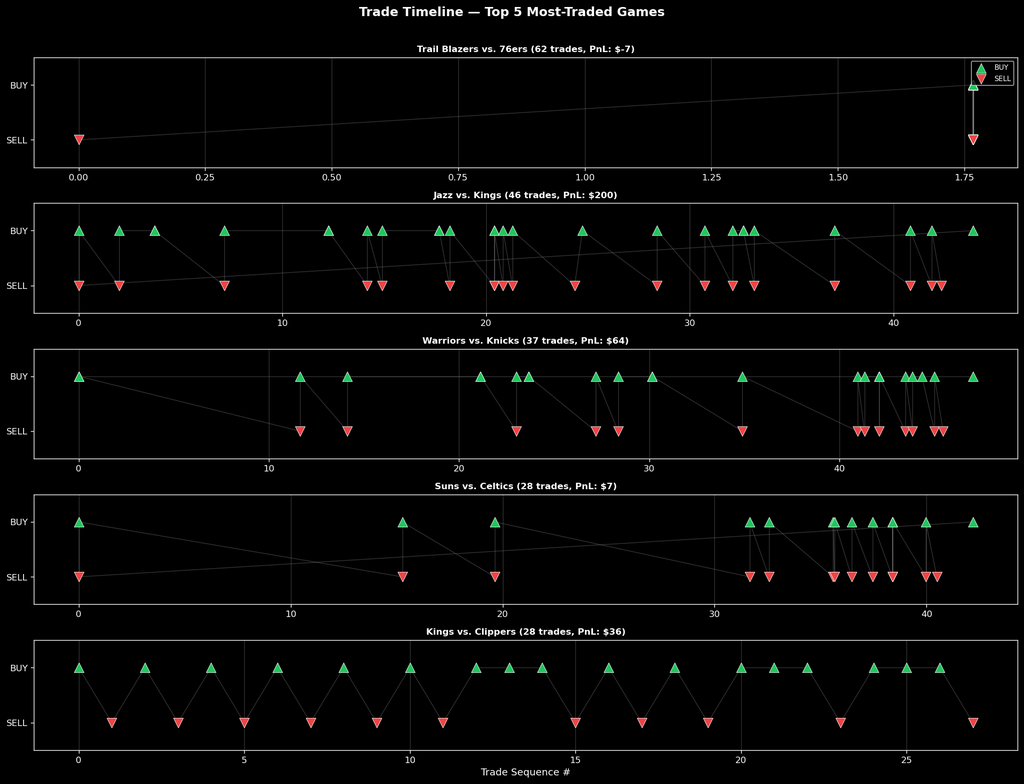

```
  ROUND-TRIP vs PnL ANALYSIS
  ==================================================
  Games WITH round-trips:   27, avg PnL: $    0.78
  Games WITHOUT round-trips:  11, avg PnL: $   -3.72
  ==================================================
```

## Section 5: Score Differential & Time Remaining at Trade

Analyze when trades fire relative to the game clock and score state. Do winning trades tend to happen at different margins or time points than losing trades?

```
  Trades with score data: 134
  Wins: 63, Losses: 71

  MARGIN AT ENTRY (from bet-side perspective)
  --------------------------------------------------
  Wins  — avg margin: +2.3, median: +2.0
  Losses — avg margin: -3.4, median: -2.0

  TIME REMAINING AT ENTRY
  --------------------------------------------------
  Wins  — avg mins left: 15.1, median: 13.4
  Losses — avg mins left: 15.4, median: 10.8

  TRADES BY QUARTER
  ------------------------------------------------------------
    Q   Count       %   Wins    Win%        PnL
  Q 1      11    8.2%      5   45.5% $   -33.18
  Q 2      16   11.9%      6   37.5% $    46.43
  Q 3      41   30.6%     24   58.5% $    64.37
  Q 4      66   49.3%     28   42.4% $  -118.93
  ------------------------------------------------------------
```

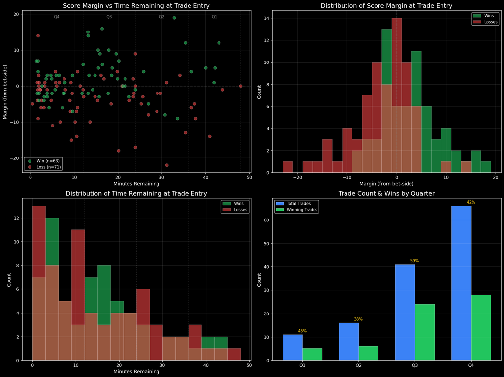

## Section 6: Bid-Ask Spread Analysis

Examine Polymarket bid-ask spreads from snapshot data and volume distribution as a proxy for liquidity conditions the bot traded in.

```
  Snapshots with bid data: 8318 / 9644
  Snapshots with ask data: 8318 / 9644

  BID-ASK SPREAD STATISTICS
  ==================================================
  Snapshots with spread data: 8318
  Mean spread:                -0.0000
  Median spread:              0.0000
  Std spread:                 0.0000
  Max spread:                 0.0000
  Mean spread (% of mid):     -0.00%

  NOTE: 4969/8318 snapshots have bid == ask (locked/no real spread)
  This suggests bid-ask data may not reflect true order book spreads.
  Estimating implementation shortfall from model vs market gap instead.

  MODEL vs MARKET GAP (Implementation Shortfall Proxy)
  ==================================================
  Mean |model - market|: 0.2380
  Median:                0.1816
  Max:                   0.7202

  POLYMARKET VOLUME (max per game)
  ==================================================
  Games with volume data: 49
  Mean volume:   $2,261,786
  Median volume: $1,971,149
  Max volume:    $5,314,245
  Min volume:    $45,708
```

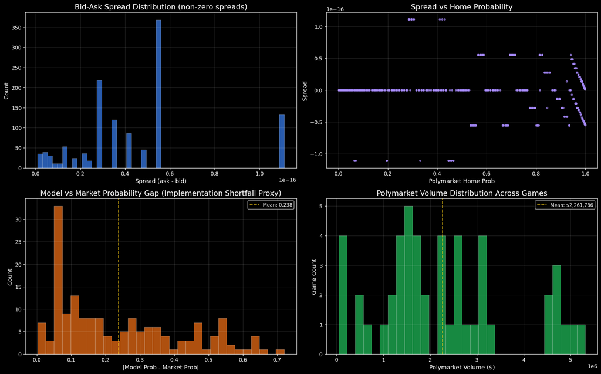

## Section 7: Sub-Model Output Decomposition

Analyze the relationship and volatility of the 5 sub-model outputs (model_win_prob, model_proxy_prob, model_margin, model_edge, model_edge_confidence) across games and over time.

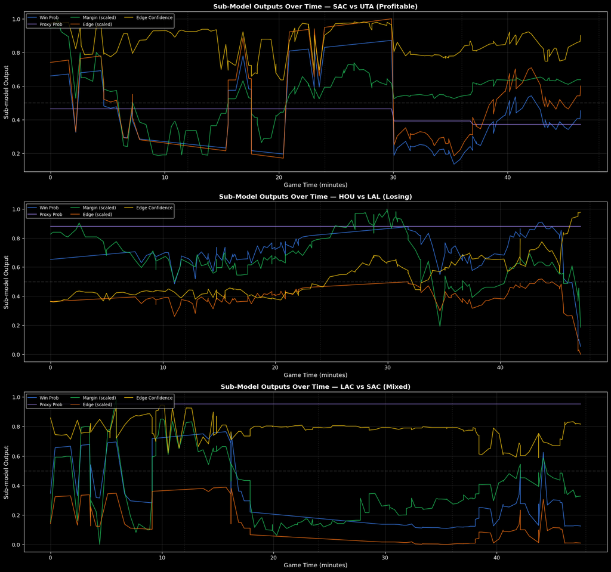

```
  TICK-TO-TICK VOLATILITY (absolute change per snapshot)
  ===========================================================================
  Sub-Model              Mean |dTick|          Std          Max    N ticks
  ---------------------------------------------------------------------------
  Win Prob                   0.017499     0.064800     0.913500       9595
  Proxy Prob                 0.000093     0.001884     0.072200       9595
  Margin                     0.785909     2.051214    54.400000       9595
  Edge                       0.017560     0.064726     0.913400       9595
  Edge Confidence            0.014037     0.034483     0.485700       9595
  ===========================================================================

  Most volatile sub-model: Margin (avg tick-to-tick swing: 0.785909)
```

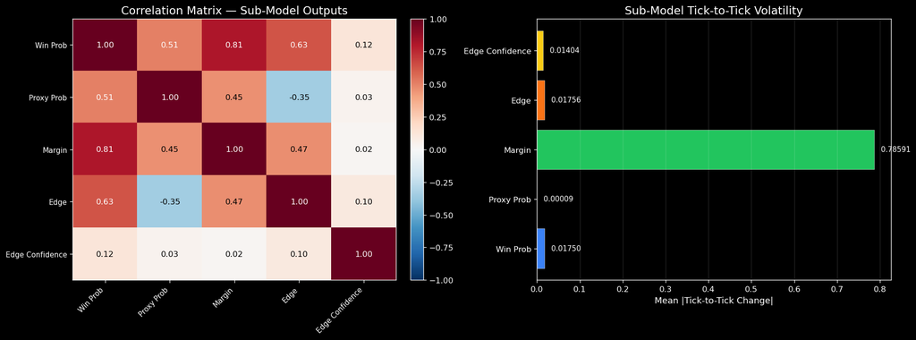

```
  CORRELATION MATRIX
  ================================================================================
                       model_win_prob  model_proxy_prob  model_margin  model_edge  model_edge_confidence
model_win_prob                  1.000             0.506         0.808       0.630                  0.118
model_proxy_prob                0.506             1.000         0.455      -0.351                  0.034
model_margin                    0.808             0.455         1.000       0.468                  0.021
model_edge                      0.630            -0.351         0.468       1.000                  0.098
model_edge_confidence           0.118             0.034         0.021       0.098                  1.000
  ================================================================================
```